# Diffusjonsvektet MRI: Et bilde av vannmolekylers virrevandring

Gruppemedlemmer: Sophia A. Wellman, Kari S. Langeland, William Dugan.

Kreft er en sykdom som fører til ukontrollert celledeling av syke celler, og det dannes svulster i kroppen vår. Når slike svulster oppstår, vil det skje en endring av diffusjon av vannmolekyler i vevet. Vannmolekylene vil få mindre plass til å bevege seg, og diffusjonen vil minke. Slik bevegelse er mulig å simulere ved programmering og numerikk. Vannmolekylene kan ses på som virrevandrere og de følger Brownske bevegelser; altså at de beveger seg ved tilfeldig spasering med hastigheter som er Gaussisk fordelt. Simulering av virrevandring i nærheten av kreftsvulster lar oss bli bedre kjent med problemet, samt tillate oss å teste ulike måter å lokalisere tumorer på. Slik kunnskap er verdifull for å kunne gi kreftpasienten lokal cellebehandling og dermed fjerne svulstene.

Dette prosjektet er todelt. Del 1 består av å utarbeide kode som beskriver fri virrevandring i én og to dimensjoner, samt hvordan dette ser ut for én og flere virrevandrere. Del 2 introduserer effekten av tumorer på virrevandrernes bevegelse i cellene. Figurene fra koden i denne delen skal vise at diffusjonen avtar der det er høy celletetthet. Vi skal i tillegg beregne intensiteten av virrevandring rundt tumorene og se at dette er en metode for å kartlegge tumorenes størrelse og posisjon.

## Oppgave 1: Frie virrevandrere i en og to dimensjoner

### 1a)

For å beskrive diffusjon ved hjelp av matematikk, er det naturlig å sette opp en differensialligning som beskriver endringer i vevstetthet som funksjon av posisjon og tid. La $\phi (x,t)$ være tettheten ved posisjon $x$ og tiden $t$. I tillegg innføres en diffusjonskonstant $D$ som en indikasjon på hvor stor diffusjonen er. Sammen gir dette følgende differensialligning:

$$ \frac{\partial \phi(x, t)}{\partial t} = D \frac{\partial^2 \phi}{\partial x^2} $$

Som mange andre naturlige fenomener, kan vevstettheten $\phi$ beskrives som en normalfordeling med forventningsverdi $\mu = 0$ og varians $\sigma^2 = at$, slik at

$$ \phi(x, t) = \frac{1}{\sqrt{2\pi at}} e^{-\frac{x^2}{2at}} $$

Videre settes dette inn i ligningen over, for å komme frem til en passende $a$.

Vi betrakter venstresiden av ligningen først, og bruker produktregel og deretter kjerneregel for derivasjon.

$$ \frac{\partial \phi(x,t)}{\partial t} = \frac{\partial}{\partial t} \left(\frac{1}{\sqrt{2\pi at}} e^{-\frac{x^2}{2at}}\right) $$$$ = \left(\frac{\partial}{\partial t} \frac{1}{\sqrt{2\pi at}}\right) e^{-\frac{x^2}{2at}} + \frac{1}{\sqrt{2\pi at}} \left(\frac{\partial}{\partial t} e^{-\frac{x^2}{2at}}\right) $$$$ = -\frac{1}{2\sqrt{2\pi a} t^{\frac{3}{2}}} e^{-\frac{x^2}{2at}} + \frac{1}{\sqrt{2\pi at}} \frac{x^2}{2at^2} e^{-\frac{x^2}{2at}} $$

Etter litt opprydning blir dette

$$ \frac{\partial \phi(x,t)}{\partial t} = \frac{1}{2t \sqrt{2\pi at}} e^{-\frac{x^2}{2at}} \left( \frac{x^2}{at} - 1 \right). $$

Når det gjelder ligningens høyreside, brukes både produktregel og kjerneregel, men ikke før den andre derivajonen. Vi gjør det steg for steg, og deriverer først en gang.

$$ D \frac{\partial^2 \phi}{\partial x^2} = D\frac{\partial^2}{\partial x^2} \left(\frac{1}{\sqrt{2\pi at}} e^{-\frac{x^2}{2at}}\right) $$$$ = -D \frac{1}{\sqrt{2\pi at}} \frac{\partial}{\partial x} \left( \frac{x}{at} e^{-\frac{x^2}{2at}}\right) $$$$ = -D \frac{1}{at \sqrt{2\pi at}} \left( \left( \frac{\partial}{\partial x} x \right) e^{-\frac{x^2}{2at}} + x \left(\frac{\partial}{\partial x} e^{-\frac{x^2}{2at}} \right)\right) $$$$ = -D \frac{1}{at \sqrt{2\pi at}} \left( e^{-\frac{x^2}{2at}} - x \frac{x}{at} e^{-\frac{x^2}{2at}} \right) $$

Skrevet på faktorisert form får vi

$$ = -D \frac{1}{at \sqrt{2\pi at}} e^{-\frac{x^2}{2at}} \left( 1 - \frac{x^2}{at} \right). $$

Nå settes venstre- og høyreside lik hverandre. Faktorer som er felles strykes, og ligningen løses for $a$.

$$ \frac{1}{2t \sqrt{2\pi at}} e^{-\frac{x^2}{2at}} \left( \frac{x^2}{at} - 1 \right) = -D \frac{1}{at \sqrt{2\pi at}} e^{-\frac{x^2}{2at}} \left( 1 - \frac{x^2}{at} \right) $$$$ \frac{1}{2} = \frac{D}{a} $$

Vi ender opp med $$ a = 2D. $$

Vi begynner med å installere de forskjellige pakkene vi trenger for prosjektet.

```python
!pip install numba==0.56.4
```

[output not shown]

```python
import numpy as np
import matplotlib.pyplot as plt
from scipy.optimize import curve_fit
from scipy import ndimage
from numba import njit
```

```python
def D(dx=1., dt=1.):
    """
    Returns the diffusionconstant in Eq. 5.

    Parameters
    ----------
    dx : float
        Increment in length. Default = 1.0
    dt : float
        Increment in time. Default = 1.0
    ----------
    """
    return dx ** 2 / (2. * dt)
```

### 1b)

Vi starter med å implementere kode for å simulere bevegelsen til én virrevandrer i én dimensjon. Det vil si at bevegelsen er begrenset til x-aksen med bestemt sannsynlighet for når den skal bevege seg til høyre og venstre. Merk at $\Delta x$ er satt til 1 gjennom hele oppgave 1. Koden returnerer et array for posisjonen til virrevandreren og et array med tilhørende tidssteg som vi bruker til å plotte senere.

```python
def brownian_single_1D(M, pr=0.5):
    """
    Brownian motion for a single particle with M steps.

    Parameters
    ----------
    M : int
        Number of moves.
    pr : float
        Probability for taking a step to the right.

    Returns
    -------
    np.array
        Time array, 1D.
    np.array
        Position array, 1D.
    """
    assert 0. < pr < 1., 'Invalid probability pr'

    positions = np.zeros(M+1)
    random_values = np.random.uniform(0, 1, M)

    for i, value in enumerate(random_values):
        if value <= pr:
            positions[i+1] = positions[i] + 1.
        else:
            positions[i+1] = positions[i] - 1.

    return np.arange(M+1), positions
```

### 1c)

I denne deloppgaven simulerer vi en virrevandrer i én dimensjon, der sannynsligheten for å gå til høyre varierer. Vi lar $p_r$ representere denne sannsynligheten, og tester med følgende verdier; $p_r = 0.45$, $0.5$ og $0.55$. Vi valgte tidssteg $M = 10\ 000$. Dette viste seg å være nok tidssteg til å gi et godt bilde på tilfeldigheten av simuleringen, og ga kort kjøretid.

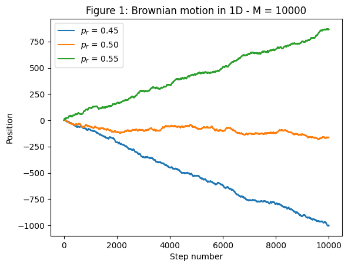

```python
M = 10_000

for pr in (0.45, 0.5, 0.55):
    plt.plot(*brownian_single_1D(M, pr), label=r'$p_r$ = '+f'{pr:.2f}')

plt.legend()
plt.xlabel('Step number')
plt.ylabel('Position')
plt.title(f'Figure 1: Brownian motion in 1D - {M = }')
plt.show()
```

Vi observerer at når $p_r > 0.5$ beveger virrevandreren seg generelt sett i positiv x-retning, som er å forvente. Tilsvarende skjer med $p_r < 0.5$, hvor virrevandreren vil bevege seg i negativ x-retning. Ved $p_r = 0.5$ holder virrevandreren seg rundt origo.

### 1d)

Vi skal nå utvide funksjonen vår fra **1b** til $N$ virrevandrere, begrenset til én dimensjon. Den mest leselige metoden for dette er å utføre samme operasjoner som i **1b**, men nå gjør vi det $N$ ganger per tidssteg.

```python
def brownian_N_1D(N, M, pr=0.5):
    """
    Brownian motion for N particles with M steps.

    Parameters
    ----------
    N : int
        Number of particles
    M : int
        Number of moves.
    pr : float
        Probability for taking a step to the right.

    Returns
    -------
    np.array
        Time array, 1D.
    np.array
        Position array, 2D.
    """
    assert 0. < pr < 1., 'Invalid probability pr'

    positions = np.zeros((M, N))
    random_values = np.random.uniform(0, 1, (M, N))
    for i in range(M):
        for j in range(N):
            if random_values[i,j] <= pr:
                positions[i,j] = positions[i-1,j] + 1.
            else:
                positions[i,j] = positions[i-1,j] - 1.

    return np.arange(M), positions
```

### 1e)

Koden i **1d** har potensialet til å gå mye raskere. En vanlig tilnærming til et slikt problem er vektorisering. I Numpy kan man utføre operasjoner på arrays (vektorer, matriser og tensorer) samtidig. Dette gjør at man kan fjerne en eller flere for-løkker slik at koden kjører raskere. Nedenfor har vi implementert vektoriserte funksjoner.

I hovedsak blir koden raskere fordi Numpy er skrevet i C/C++, hvor løkker kjører betydelig mye raskere enn i et høynivåspråk som Python. I tillegg har vi valgt å bruke Numba. Numba er en pakke som 'oversetter' Python-funksjoner til LLVM-kode. Dette er et lavnivåspråk som går raskere, og er i tillegg laget for å fungere spesielt bra sammen med Numpy. Totalt antall utregninger forblir likt, men utførelsen går raskere.

Vi merker oss at koden blir betydelig mye vanskeligere å lese/forstå, i tillegg til at det blir vanskeligere å modifisere og feilsøke.

```python
def brownian_N_1D_vectorized(N, M, pr=0.5):
    """
    Brownian motion for N particles with M steps.

    Parameters
    ----------
    N : int
        Number of particles
    M : int
        Number of moves.
    pr : float
        Probability for taking a step to the right.

    Returns
    -------
    np.array
        Time array, 1D.
    np.array
        Position array, 2D. (M, N)
    """
    assert 0. < pr < 1., 'Invalid probability pr'

    random_values = np.random.uniform(0, 1, (M, N))
    steps = np.where(random_values <= pr, +1, -1)
    positions = np.cumsum(steps, axis=0)

    return np.arange(M), positions
```

Vi skal nå teste funksjonene i **1d** og **1e** opp mot hverandre. Her brukes det $N = 1000$ virrevandrere, $M = 1000$ tidssteg og sannsynlighet $p_r = 0.5$.

```python
print("Ikke-vektorisert kode:")
%timeit brownian_N_1D(N=1000, M=1000, pr=0.5)
print("Vektorisert kode:")
%timeit brownian_N_1D_vectorized(N=1000, M=1000, pr=0.5)
```

```
Ikke-vektorisert kode:
401 ms ± 9.92 ms per loop (mean ± std. dev. of 7 runs, 1 loop each)
Vektorisert kode:
19.4 ms ± 132 µs per loop (mean ± std. dev. of 7 runs, 100 loops each)
```

Vi observerer at den vektoriserte koden kjører vesentlig raskere enn den som bruker for-løkker. Det er god overenstemmelse med forventningene.

### 1f)

Fra simuleringene våre kan vi regne ut den empiriske variansen. Denne kan vi sammenligne med den analytiske; $\sigma^2 = a \cdot t$. Ved en slik sammenligning kan vi sjekke hvor nærme den numeriske tilnærmingen passer den teoretiske virkeligheten. Den empiriske variansen er regnet ut med bruk av `numpy.var(data, axis, ddof)`. Siden vi ønsker variansen som en funskjon av tid, og dimensjonen til dataen vår er (M, N), forteller vi funksjonen at utregningene gjøres over den andre aksen (`axis=1`). "The Delta Degrees of Freedom" (ddof) er antall frihetsgrader som skal brukes i formelen, og denne må settes til 1 for å få varians slik vi kjenner det fra statistikken.

```
Linear fit: a = 0.914, b = 13.598
```

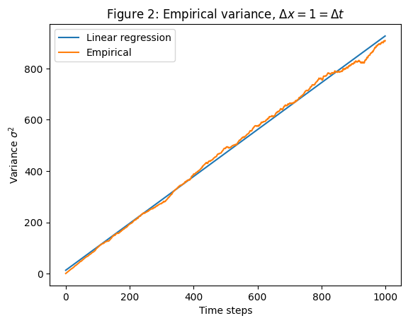

```python
t, pos = brownian_N_1D_vectorized(N=1000, M=1000, pr=0.5)
sigma_sq = np.var(pos, axis=1, ddof=1)

a, b = curve_fit(lambda x, a, b: a*x + b, xdata=t, ydata=sigma_sq)[0]
print(f'Linear fit: a = {a:.3f}, b = {b:.3f}')

plt.plot(t, a*t+b, label='Linear regression')
plt.plot(t, sigma_sq, label='Empirical')
plt.title(r'Figure 2: Empirical variance, $\Delta x = 1 = \Delta t$')
plt.xlabel('Time steps')
plt.ylabel(r'Variance $\sigma^2$')
plt.legend()
plt.show()
```

Hvis man ønsker at den emipriske variansen skal samsvare i større grad med det analytiske resultatet i **1a** burde man øke antall virrevandrere, $N$. En økning i antall tidssteg, $M$, ville ført til flere nye varianser, altså en større verdimengde langs y-aksen. Det ville ført til å minke den prosentvise feilen for $b$-verdien, da vi kan dele på et større tall, men hver verdi for variansen ville ikke blitt mer nøyaktig med hensyn på det analytiske resultatet. Derfor vil det hjelpe å øke antall virreandrere. Med flere virrevandrere vil det genereres flere datapunkter for hver $\sigma$, slik at når dette tallet blir stort, konvergerer variansen mot den analytiske verdien.

### 1g)

Vi skal nå utvide funksjonen i **1d** til å gjelde for $N$ virrevandrere i to dimensjoner. Vi har tatt med oss vektoriseringen fra **1e**, men vi må regne ut antall steg i henholdsvis x- og y-retning. Disse er uavhengig av hverandre, og kan derfor regnes ut individuelt.

`move_hoizontal` er en vektor med like mange elementer som tidssteg og virrevandrere, og avgjør om virrevandrerene skal bevege seg i x-, *eller* y-retning.

```python
def brownian_N_2D(N, M, pr=0.5, pu=0.5):
    """
    Brownian motion for N particles with M steps in two dimensions.

    Parameters
    ----------
    N : int
        Number of particles
    M : int
        Number of moves.
    pr : float
        Probability for taking a step to the right.
    pu : float
        Probability for taking a step upwards.

    Returns
    -------
    np.array
        Time array, 1D.
    np.array
        Position array, 3D. Dimension ( M, N, (x,y) ).
    """
    assert 0. < pr < 1., 'Invalid probability pr'
    assert 0. < pu < 1., 'Invalid probability py'

    positions = np.zeros((M, N, 2))
    random_values = np.random.uniform(0, 1, size=positions.shape)
    move_horizontal = np.random.uniform(0, 1, size=(M,N)) <= 0.5
    steps_x = np.where(random_values[:,:,0] < pr, +1, -1) * move_horizontal
    steps_y = np.where(random_values[:,:,1] < pu, +1, -1) * (1. - move_horizontal)
    positions[:,:,0] += steps_x
    positions[:,:,1] += steps_y

    return np.arange(M), np.cumsum(positions, axis=0)
```

Nå skal vi teste implementasjonen av funksjonen med $N = 4$ virrevandrere og $M = 1000$ tidssteg.

#### Isotropt system

Vi begynner med å se på et isotropt system, det vil si at sannsynligheten for å bevege seg i x- eller y-retning er den samme ($p_r = 0.5 = p_u$).

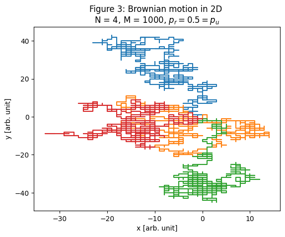

```python
N = 4
M = 1000
t, pos = brownian_N_2D(N, M)

# For every atom, plot the scatter plot of position in x and y for all time points
for n in range(N):
    plt.plot(pos[:,n,0], pos[:,n,1])

plt.xlabel('x [arb. unit]')
plt.ylabel('y [arb. unit]')
plt.title(f'Figure 3: Brownian motion in 2D \nN = 4, M = 1000, ' + r'$p_r = 0.5 = p_u$')
plt.show()
```

I figuren ser vi ingen tydelige trender, som stemmer godt overens med isotropien i simuleringen.

#### Anisotropt system

Her velger vi ulike sannsynligheter for bevegelse i x- og y-retning ($p_r \neq 0 \neq p_u$). Vi har valgt $p_r = 0.65$ og $p_u = 0.35$.

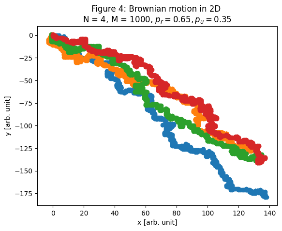

```python
t, pos = brownian_N_2D(N, M, pr=0.65, pu=0.35)

# For every atom, plot the scatter plot of position in x and y for all time points
for n in range(N):
    plt.scatter(pos[:,n,0], pos[:,n,1])

plt.xlabel('x [arb. unit]')
plt.ylabel('y [arb. unit]')
plt.title(f'Figure 4: Brownian motion in 2D \nN = 4, M = 1000, ' + r'$p_r = 0.65, p_u = 0.35$')
plt.show()
```

Med $p_r = 0.65$ og $p_u = 0.35$ forventer vi at virrevandrerne vil bevege seg i positiv x-retning og negativ y-retning. En slik trend ser vi i figuren. Med andre ord kan vi si at anisotropien i systemet er tydelig.

### 1h)

Enn så lenge er det ikke implementert grensebetingelser for virrevandrerne, som betyr at de kan bevege seg fritt over hele xy-planet. Dette kan muligens være problematisk dersom man ønsker å studere et avgrenset område. Vi skal derfor nå sjekke om virrevandrerne vil forsvinne langt ut på xy-planet uten å returnere til sine startposisjoner, eller om de vil finne veien tilbake. Dersom det sistnevnte skjer, vil det ikke være like problematisk at man har et system uten grensebetingelser så lenge man simulerer med nok tidssteg for at virrevandrerne får muligheten til å bevege seg til det aktuelle området igjen.

Våre virrevandrere er plassert slik at startposisjonen deres er i origo. For å telle hvor mange ganger en virrevandrer har vært innom origo i løpet av en tid $t$, har vi valgt å dele opp implementasjonen i to funksjoner. Den første gjelder for bevegelse i én dimensjon, og den andre for to dimensjoner. Funksjonene fungerer på samme måte, men origo er definert ulikt (0 for 1D, (0,0) for 2D).

Merk at dersom en virrevandrer er innom origo mer enn én gang, blir den ikke telt med. Dette gjøres ved å lagre indeksen til virrevandreren første gang den befinner seg i origo. I tillegg antas det at hver virrevandrer forflytter seg hvert tidssteg. Om dette ikke hadde vært tilfellet, ville diffusjonen vært lavere.

#### P(x=0, t=1) for 1D og 2D

Med initialposisjon i origo, er sannsynligheten for at en virrevandrer fortsatt befinner seg på samme sted etter første endte tidssteg null, nettopp på grunn av betingelsen om at en virrevandrer ikke kan stå stille. Dette gjelder alltid, uavhengig av hvor mange dimensjoner den kan bevege seg i.

Figuren under viser valgtrær som brukes for å komme frem til sannsynligheten for at en virrevandrer går tilbake til origo etter andre tidssteg. Konvensjonen er prikk for hver posisjon, og over/under prikkene står posisjonens tilhørende koordinat. Strekene er mulige veier for virrevandrerne, og hvert veivalg har en sannsynlighet knyttet til seg. For å komme frem til sannsynligheten for å returnere tilbake til origo etter to tidssteg, ser man på siste rad med prikker. Prikkene som korresponderer til origo har en tilhørende sannsynlighet, og disse summeres opp. La oss se nærmere på det for hver av figurene.

#### P(x=0, t=2) for 1D

I **Figur 5** finner vi valgtreet som representrerer virrevandrernes mulige forflytninger i én dimensjon etter to tidssteg. Med enkel matematikk blir dette $\frac{1}{4} + \frac{1}{4} = \frac{1}{2}$. Det er altså $50$% sannsynlig å finne virrevandreren i origo etter to tidssteg.

#### P(x=0, t=2) for 2D

Valgtreet i **Figur 6** er representativt for to dimensjoner etter to tidssteg. Valgmulighetene øker kvadratisk, og det blir fire ulike måter å komme seg tilbake til origo på ved å la virrevandrerne ta to veivalg hver. Vi summerer opp sannsynlighetene og kommer frem til at det er $0.0625* 4 = 0.25 = 25$% sannsynlig for en virrevandrer å returnere tilbak til origo.

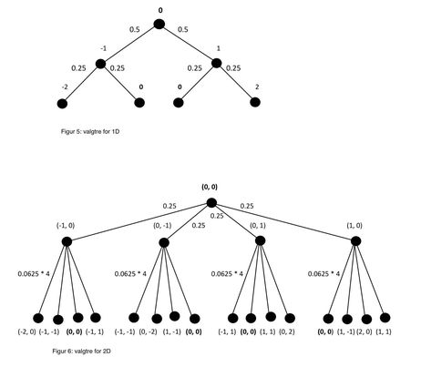

```python
from IPython import display
display.Image("/work/valgtre_endelig_bilde.jpg")
```

#### Beregning av $n(t)$

Her implementerer vi de to funksjonene for å telle andelen virrevandrere som har vært innom origo før en tid $t$. Merk at virrevandrerene kun telles en gang, selv om de muligens er innom origo mer enn én gang.

```python
@njit
def count_zeros_N_1D(positions: np.ndarray):
    """
    Calculates n(t) for N particles in 1D.

    Parameters
    ----------
    positions : np.ndarray, (M, N)
        Positional array with time as first axis.

    Returns
    -------
    np.ndarray, (M,)
        Time array.
    np.ndarray, (M,)
        Array with n(t) values.
    """
    M, N = positions.shape
    n = np.zeros(M)
    been_to_origo_indicies = []

    for t in range(1, M):
        count = 0
        for i in range(N):
            if positions[t,i] == 0:
                if not (i in been_to_origo_indicies):
                    been_to_origo_indicies.append(i)
                    count += 1

        n[t] = n[t-1] + count / N

    return np.arange(M), n
```

```python
@njit
def count_zeros_N_2D(positions: np.ndarray):
    """
    Calculates n(t) for N particles in 2D.

    Parameters
    ----------
    positions : np.ndarray, (M, N, (x,y))
        Positional array with time as first axis.

    Returns
    -------
    np.ndarray, (M,)
        Time array.
    np.ndarray, (M,)
        Array with n(t) values.
    """
    M, N, _ = positions.shape
    n = np.zeros(M)
    been_to_origo_indicies = []

    for t in range(1, M):
        count = 0
        for i in range(N):
            in_origo = positions[t,i,0] == 0 and positions[t,i,1] == 0
            if in_origo:
                if not (i in been_to_origo_indicies):
                    been_to_origo_indicies.append(i)
                    count += 1

        n[t] = n[t-1] + count / N

    return np.arange(M), n
```

### 1i)

Vi velger $N = 100$ virrevandrere og $M = 100\ 000$ tidssteg for å kjøre simuleringer i én og to dimensjoner av isotrope systemer. Ved kjøring av lavere tidssteg får vi fortsatt rask konvergens for $n(t)$ i én dimensjon. Likevel viser det seg at 100 000 tidssteg er for lite for at $n(t)$ skal konvergere mot 1 ved simulering i to dimensjoner. Dette er å forvente når vi ser tilbake på de analytiske sannsynlighetsverdiene vi regnte ut ovenfor.

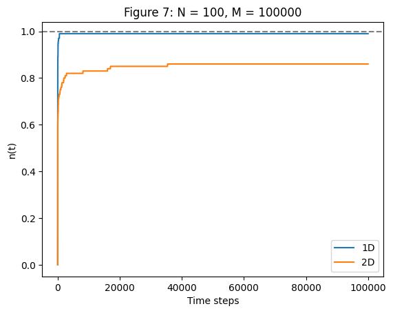

```python
N = 100
M = 100_000

# Isotrop system
_, pos = brownian_N_1D_vectorized(N, M)
t, n = count_zeros_N_1D(pos)
plt.plot(t, n, label='1D')

# Non-isotrop system
_, pos = brownian_N_2D(N, M)
t, n = count_zeros_N_2D(pos)
plt.plot(t, n, label='2D')

plt.xlabel('Time steps')
plt.ylabel('n(t)')
plt.title("Figure 7: " + f'{N = }, {M = }')
plt.axhline(y=1, ls='--', c='k', alpha=0.5)
plt.legend()
plt.show()
```

Ved simulering med $N = 1000$ virrevandrere får vi følgende feilmelding:

> `KernelInterrupted: Execution interrupted by the Jupyter kernel.`

Dette kommer av at vår Jupyter kernel kjøres på en gratisserver med begrenset minne. Ved å kjøre koden fra terminalen eller en IDE kan man øke $N$ til høyere verdier. Dette er grunnen til at $N = 100$ er valgt. Det samme gjelder for høyere verdier av $M$. Vi ønsker likevel å ha $N$ og $M$ så høye som mulig for å få en tilstrekkelig mengde med data som kan generere trender som er representative for det vi ønsker å plotte.

Ved å plotte for ulike verdier av $M$ og $N$, har vi observert to sammenhenger. Ved å øke $M$, og la $N$ være konstant, vil ikke konvergenstiden øke, men vi får et større datasett som gir mulighet for å følge utviklingen lenger. For å kunne observere en konvergens, kreves det en for stor $M$ for vår Jupyter kernel. Det blir dermed ikke mulig for oss å øke $M$ her for å konstatere konvergensen.

Dersom vi øker $N$, og lar $M$ være konstant derimot, avtar konvergenstiden. Sagt på en annen måte, med flere virrevandrere kreves det færre tidssteg for å få alle tilbake til origo, og grafen går raskere mot 1. Dette er et uforvnetet resultat, da virrevandrerne skal være uavhengig av hverandre.

## Oppgave 2: Diffusjon av vannmolekyler i hjernen

I denne delen av prosjektet skal vi implementere tumorer som vannmolekylene (virrevandrerne) diffunderer rundt. Vi skal bruke koden fra Oppgave 1 som simulerer virrevandrernes bevegelse og tilpasse denne til å passe et system der den blir begrenset av økt tetthet av celler (tumorer). Dette skal fremstilles i figurer som viser både bevegelsen til vannmolekylene og tumorene. Videre skal vi beregne intensitet av virrevandrere i et rutenett med bestemt oppløsning og sammenligne dette med posisjonene til tumorene. Denne intensiteten blir filtrert ved hjelp av Sobel-filtere.

### 2a)

Vi har valgt å beholde tallverdiene til $\Delta x$ og $\Delta t$ i henholdsvis millimeter og sekund. Dette gjør at utregningsdelen av koden forblir den samme, men at vi må huske på at avstander er i millimeter når vi plotter figurer osv. Vi definerer de globale konstantene `DX_MM = 0.004` og `DT_S = 0.01` for å ha de lett tilgjengelig i resten av koden.

Med $\Delta x = 0.004$ mm og $\Delta t = 0.01$ s får vi følgende verdi for diffusjonskonstanten $D$:

```python
DX_MM = 0.004
DT_S = 0.01

print(f'D = {D(DX_MM, DT_S):.2e} mm^2/s')
```

```
D = 8.00e-04 mm^2/s
```

### 2b)

Algoritmen for å regne ut effektiv $\Delta x$ består av å sjekke avstanden fra et gitt punkt $(x, y)$ til alle tumor-sentrene, og sammenligne denne med radiusen av tumorene. Her har vi altså antatt at tumor-sentrene ikke endrer seg over tid, og at alle tumorene er sirkulære med samme areal (radius). Videre følger algoritmen samme metode som beskrevet i oppgaveteksten.

I denne koden har vi har valgt bort 'smarte' Numpy-funksjoner som `numpy.where`, og lignende, for at feilsøking skal bli lettere å utføre. Numba er brukt her slik at vi kan senke kjøretiden til koden.

```python
@njit
def dx_effective(x, y, tumor_pos, area, tk):
    """
    Calculate the effective dx value for points in the xy-plane.

    Parameters
    ----------
    x : foat
        Position in x direction
    y : float
        Position in y direction
    tumor_pos : np.ndarray
        ( m, (x,y) ) array with positions of centers of tumors.
    area : float
        Area of tumors. Same length unit as position.
    tk : np.ndarray
        (m,) array with tumor coefficients.

    Returns
    -------
    float
        Effective dx value in point (x, y).
    """
    m = tumor_pos.shape[0]
    tk_eff = 1.
    radius = np.sqrt(area / np.pi)

    for mi in range(m):
        tumor = tumor_pos[mi]
        x_dist = tumor[0] - x
        y_dist = tumor[1] - y
        pos = np.asarray((x_dist,y_dist))
        dist = np.linalg.norm(pos)
        if dist < radius:
            tk_eff *= tk[mi]

    return DX_MM * np.sqrt(tk_eff)
```

### 2c) og 2d)

I koden nedenfor modifiserer vi virrevandrer-funksjonen fra **Oppgave 1** for å ta inn en variabel $\Delta x$.

#### Periodiske randbetingelser

Periodiske randbetingelser er implementert i koden, men de kan skrus av og på. Merk at randen er kvadratet $[0, L]\times[0, L]$. Dermed er $x_{\text{min}} = 0 = y_{\text{min}}$ og $x_{\text{max}} = L = y_{\text{max}}$. Vi har også antatt $n_x = n_y$ i de resterende oppgavene, men koden er implementert slik at $n_x$ og $n_y$ kan endres uavhengig av hverandre.

Det er flere fordeler med periodiske randbetingelser. Den første er at den er simpel å implementere, samt enkel å verifisere. Den kan også vektoriseres, slik at den fungerer både i én og to dimensjoner. Med periodiske randbetingelser begrenser vi virrevandrerne til et bestemt og avgrenset område. Dette fungerer spesielt bra da tumorene (her) befinner seg i et lite område i $xy$-planet. Dette gjør at man enklere kan danne et godt bilde av diffusjonen i området av intresse (hvor tumorene befinner seg) med færre tidssteg enn hvis man for eksempel hadde brukt åpne randbetingelser.

En ulempe med periodiske randbetingelser kan være at det fungerer dårlig med `plt.plot`. Dette er på grunn av at når virrevandreren går gjennom en vegg, så vil den komme ut på andre siden, og en slik bevegelse vil føre til en strek på tvers av figuren. Dette er løst med å bruke `plt.scatter` når vi bruker periodiske randbetingelser.

Vi har i tillegg endret koden slik at hver virrevandrer begynner i en tilfeldig valgt posisjon innenfor kvadratet $[0, L]\times[0, L]$. Dette gjør at vi detekterer flere tumorer med intensitetsberegningen, som vil bli diskutert i **2f**.

#### Modifikasjon av virrevandrer-simulering

```python
@njit
def brownian_N_2D_tumor(N, M, tumor_pos, tk, area, L=None, pr=0.5, pu=0.5):
    """
    Brownian motion for N particles with M steps in two dimensions.

    Parameters
    ----------
    N : int
        Number of particles
    M : int
        Number of moves.
    tumor_pos : np.ndarray
        ( m, (x,y) ) array with coordinates of tumor centers.
    tk : np.ndarray
        (m,) array with tumor coefficients.
    area : float
        Area of tumors (constant).
    L : float
        Length of bounding box (0, L) x (0, L).
    pr : float
        Probability for taking a step to the right.
    pu : float
        Probability for taking a step upwards.

    Returns
    -------
    np.array
        Time array, 1D.
    np.array
        Position array, 3D. Dimension ( M, N, (x,y) ).
    """
    assert 0. < pr < 1., 'Invalid probability pr'
    assert 0. < pu < 1., 'Invalid probability pu'
    if L is not None:
        assert L > 0., 'Invalid value L'
        positions = np.random.uniform(0, L, size=(M,N,2))
    else:
        positions = np.zeros((M, N, 2))

    random_values = np.random.uniform(0, 1, size=(M,N))
    move_horizontal = np.random.uniform(0, 1, M) <= 0.5

    for t in range(0, M-1):
        for n in range(N):
            x, y = positions[t,n,0], positions[t,n,1]
            dx_eff: float = dx_effective(x, y, tumor_pos, area, tk)

            if move_horizontal[t]:
                # Keep y coordinate
                positions[t+1,n,1] = positions[t,n,1]

                # Update x coordinate
                if random_values[t,n] <= pr:
                    positions[t+1,n,0] = positions[t,n,0] + dx_eff
                else:
                    positions[t+1,n,0] = positions[t,n,0] - dx_eff
            else:
                # Keep x coordinate
                positions[t+1,n,0] = positions[t,n,0]

                #Update y coordinate
                if random_values[t,n] <= pu:
                    positions[t+1,n,1] = positions[t,n,1] + dx_eff
                else:
                    positions[t+1,n,1] = positions[t,n,1] - dx_eff

            # Periodic boundary conditions
            if L is not None:
                positions[t+1,n] -= np.floor(positions[t+1,n] / L) * L

    return np.arange(M), positions
```

#### Simulering

Her begynner simuleringen. Merk at periodiske randbetingelser er deaktivert.

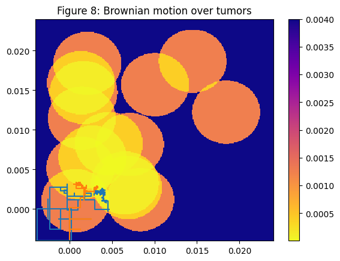

```python
# Valus given in task
N = 2
M = 1000
m = 15
L = 0.02  # [mm]

tumor_pos = np.random.uniform(0, L, size=(m,2))
tk = np.full(shape=m, fill_value=0.1)
area = np.pi * DX_MM ** 2
t, pos = brownian_N_2D_tumor(N, M, tumor_pos, tk, area)

# To plot tumors in colors / dx_eff
xmin, xmax = -DX_MM, L + DX_MM
ymin, ymax = -DX_MM, L + DX_MM

# Calculating DX for color plot
n = 300
x = np.linspace(xmin, xmax, n)
y = np.linspace(ymin, ymax, n)
dx = np.zeros((n,n))
for xi in range(n):
    for yi in range(n):
        dx[yi,xi] = dx_effective(x[xi], y[yi], tumor_pos, area, tk)

c = plt.pcolormesh(x, y, dx, cmap='plasma_r')
plt.colorbar(c)

# Plotting random walk
for n in range(N):
    plt.plot(pos[:,n,0], pos[:,n,1])

plt.xlim(xmin, xmax)
plt.ylim(ymin, ymax)
plt.title('Figure 8: Brownian motion over tumors')
plt.show()
```

`plt.colorbar` viser den effektive $\Delta x$ verdien i et gitt punkt. Vi ser tydelig hvor tumorene befinner seg. Det er god overenstemmelse med effektiv $\Delta x$ verdi og tumor-overlapp. I områdene med flere tumorer er reduksjonskoeffisienten lav, som gir en lav verdi for $\Delta x$ (husk at alle $t_k < 1$). Dette forteller oss at diffusjonen avtar i områder med høyere celletetthet, noe som stemmer overens med virkeligheten.

### 2e)

```python
def intensity(nx, ny, xmin, xmax, ymin, ymax, positions):
    """
    This function calculates the intensity of random walkers in each square of a grid nx*ny.

    Parameters
    ----------
    nx : int
        Number of rows
    ny : int
        Number of columns
    xmin : float
        Lowest value of x in our grid
    xmax : float
        Highest value of x in our grid
    ymin : float
        Lowest value of y in our grid
    ymax :
        Highest value of y in our grid
    positions : np.ndarray[float]
        shape = (M, N, 2). Matrix of our random walkers' positions for each timestep, M

    Returns
    ----------
    I : np.ndarry[float]
        Normalised matrix that contains the intensity of random motion in each sqaure nxny.
    """
    I = np.zeros((nx,ny), dtype=float) #Her skal intensitetene lagres
    M = positions.shape[0] #Henter ut tallet M som er første indeks i positions sin shape
    N = positions.shape[1] #Henter ut tallet N som er andre indeks i positions sin shape

    for t in range(M):
        I += np.histogram2d(x = positions[t, :, 1], y = positions[t, :, 0], bins = (nx, ny), range = [[xmin,xmax], [ymin,ymax]])[0]
        #np.histogram returnerer flere ting, vi ønsker bare første element ([0]) som er selve histogrammet

    I = np.flip(I, axis=0)  # ???
    return I / (M * N)
```

### 2f)

Vi har valgt $N = 1000$ virrevandrere og $M = 1000$ tidssteg. Dette danner et godt bilde av tumorene og gir kort kjøretid, i tillegg til at det fungerer med den begrensede mengen minne (se **1i**). Vi bruker $m = 15$ tumorer, $L = 0.02$ mm, og $a = \pi(\Delta x)^2$ mm$^2$ slik som i **2c**. Dette gjør at vi enkelt kan sammenligne nye resultater med de foregående.

Vi har valgt å legge på interpolasjon på figuren av intensiteten for å minke effekten av diskretiseringen som skjer i numerisk simulering.

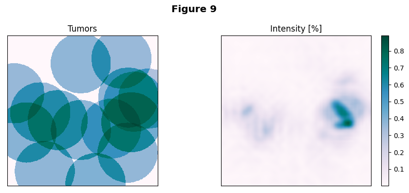

```python
N = 1000
M = 1000
m = 15
L = 0.02  # [mm]
nx = 40
ny = 40

xmin, xmax = 0, L
ymin, ymax = 0, L

tumor_pos = np.random.uniform(xmin, xmax, size=(m,2))
tk = np.random.uniform(0.3, 0.45, size=m)
area = np.pi * DX_MM ** 2
t, positions = brownian_N_2D_tumor(N, M, tumor_pos, tk, area, L)
I = intensity(nx, ny, xmin, xmax, ymin, ymax, positions)

# Calculating DX for color plot
nr = 400
x = np.linspace(xmin, xmax, nr)
y = np.linspace(ymin, ymax, nr)
dx = np.zeros((nr,nr))
for xi in range(nr):
    for yi in range(nr):
        dx[yi,xi] = dx_effective(x[xi], y[yi], tumor_pos, area, tk)

fig, ax = plt.subplots(
    ncols=2, sharex=False, sharey=False, figsize=(9, 4),
    subplot_kw={'xticks': [], 'yticks': []}  # Removes axes ticks and numbers
)

# Plotting figure of tumors
im = ax[0].pcolormesh(x, y, dx, cmap='PuBuGn_r')
# im = ax[0].imshow(dx, cmap='plasma_r')
ax[0].set(title='Tumors', xlim=(xmin, xmax), ylim=(ymin,ymax), aspect='equal')
# plt.colorbar(im, ax=ax[0], fraction=0.045)

# Plotting figure of intensity
im = ax[1].imshow(I*100, cmap='PuBuGn', interpolation='bessel')
ax[1].set(title='Intensity [%]', aspect='equal')
plt.colorbar(im, ax=ax[1], fraction=0.045)

plt.suptitle('Figure 9', size='x-large', weight='bold')
plt.tight_layout()
plt.show()
```

Fra **Figur 9** ser vi overenstemmelser mellom bildet av tumorene og bildet av intensiteten. Der det er høy intensitet av bevegelse, er det også overlappende tumorer. Det gir mening da tumorene vil begrense virrevandrerne slik at det er vanskeligere for dem å bevege seg fritt, og da blir de fanget inni tumorene. Siden dette reflekteres i intensiteten av virrevandrer-bevegelsen, er det logisk at man kan bruke slik intensitet til å detektere tumorenes posisjon og størrelse.

### 2g)

#### Implementering av Sobel-filter

Vi definerer to funksjoner, en som utfører filtreringen, og en som plotter resultatene. Vi har valgt å bruke `scipy.ndimage.sobel` ettersom funksjoner i de store Python-bibliotekene ofte er raske og enkle å bruke.

```python
def sobel(im):
    """
    Applies Sobel filter on greyscale image.

    Parameters
    ----------
    im : np.ndarray[int]
        (nx, ny) Array containing values for greyscale image.

    Returns
    -------
    Sx : np.ndarray[int]
        (nx, ny) Sobel filter result in X direction.
    Sy : np.ndarray[int]
        (nx, ny) Sobel filter result in Y direction.
    mag : np.ndarray[int]
        (nx, ny) Sobel filter normalized magnitude.
    """
    Sx = ndimage.sobel(im, axis=0)
    Sy = ndimage.sobel(im, axis=1)
    magnitude = np.sqrt(Sx ** 2 + Sy ** 2)
    magnitude *= 255. / np.max(magnitude)  # Normalizing
    return Sx, Sy, magnitude

def plot_sobel(im, figurenumber, show=False):
    """
    Apply Sobel filter on a greyscale image and plot the result.

    Parameters
    ----------
    im : np.ndarray[int]
        (nx, ny) Array containing values for greysacle image.
    show : bool
        Default False. Triggers plt.show().
    figurenumber : int
        Figure number in title.

    Returns
    -------
    plt.figure()
        Subplot figure.
    """
    fig, ax = plt.subplots(
        2, 2, sharex=True, sharey=True, figsize=(9, 6),
        subplot_kw={'xticks': [], 'yticks': []}  # Removes axes ticks and numbers
    )
    cmap = 'Greys_r'  # Greysacle colormap
    Sx, Sy, mag = sobel(im)

    # Plotting original figure
    ax[0,0].imshow(im, cmap)
    ax[0,0].set(title='Original')

    # Plotting Sobel x direction
    ax[0,1].imshow(Sx, cmap)
    ax[0,1].set(title='X')

    # Plotting Sobel y direction
    ax[1,0].imshow(Sy, cmap)
    ax[1,0].set(title='Y')

    # Plotting Sobel magnitude
    ax[1,1].imshow(mag, cmap)
    ax[1,1].set(title='S')

    plt.suptitle(f'Figure {figurenumber}: Sobel filter', size='x-large', weight='bold')
    plt.tight_layout()

    if show:
        plt.show()
```

#### Anvendelse av Sobel-filter

Nå anvender vi filteret på intensiteten som ble regnet ut i **2f**.

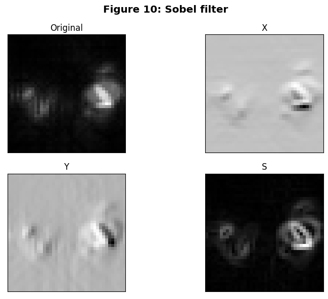

```python
fig = plot_sobel(I, 10)
```

Vi ser at $n_x = 40 = n_y$ er en for lav oppløsning gitt at $L = 0.02$ mm og $a = \pi(\Delta x)^2$. Man skal likevel være forsiktig at man ikke velger $n$ for høy. Da vil man introdusere mye støy i bildet, og tumorene vil 'vaskes bort' i støyet.

Nedenfor er samme intensitet plottet for $n_x = n_y = 80$. Da ser vi at den bedre oppløsningen gir et tydeligere omriss av tumorene slik at det blir enklere å skille dem.

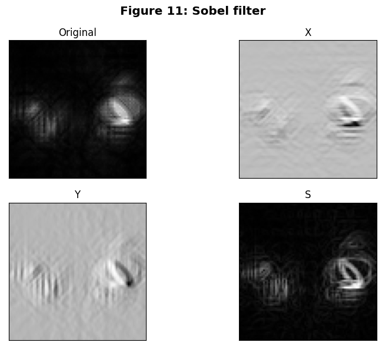

```python
nx, ny = (80, 80)
I = intensity(nx, ny, xmin, xmax, ymin, ymax, positions)
fig = plot_sobel(I, 11)
```

I dette prosjektet har vi simulert tilfeldig spasering av vannmolekyler i friskt og sykt vev. Vi har undersøkt fri bevegelse av virrevandreren i både én og to dimensjoner, og sett på hvordan endringen av celletetthet påvirker denne bevegelsen. Det numeriske resultatet viste at diffusjon av virrevandrerne vil avta drastisk slik at de blir "fanget" der det er høy celletetthet, altså der det er kreftsvulster. Dette stemmer godt overens med forventningene våre av deres oppførsel. Vi har videre undersøkt dersom å måle intensiteten av bevegelse i nærheten av tumorene er en mulig metode for å lokalisere dem på samt undersøke størrelsen deres. Figurene fra denne koden viser at det er overenstemmelse mellom intensiteten i virrevandringen og posisjonen til tumorene. Dermed kan man konkludere at det er en mulig metode for å bestemme hvor kreftsvulstene ligger i vevet. En annen metode for å identifisere tumorenes lokasjon på, hadde vært å ta i bruk magnetisk resonans. Ved å utnytte vannmolekylers dipolmoment, kan et eksternt magnetfelt avsløre posisjonene deres. De små magnetene innretter seg etter magnetfeltet, og når feltet skrus av, roterer magnetene tilbake til utgangsposisjonen, og et foton sendes ut. Med kompliserte tilnærminger, kan posisjonene avbildes og vi får et MR-bilde.

[figure not shown]

Created in Deepnote